# S6_Gene_Lists_to_Biology

Enrique Audain Martinez

2026-09-18

S5 produced a list of differentially expressed genes. This lesson covers how to characterise such a list using public databases and enrichment analysis, and how to assess whether an enrichment result is supported by the genes behind it.

## 1. Load libraries

```r
library(dplyr, quietly = TRUE)
library(readr, quietly = TRUE)
library(ggplot2, quietly = TRUE)
```

## 2. Load the differential expression results

```r
# The results table written by S4, and visualised in S5.
res = read_tsv("../../results/DESeq2_results.tsv", show_col_types = FALSE)

head(res)
```

```
## # A tibble: 6 x 7
##   gene         baseMean log2FoldChange lfcSE    stat pvalue  padj
##   <chr>           <dbl>          <dbl> <dbl>   <dbl>  <dbl> <dbl>
## 1 LOC100000024    35.0          1.25   0.671  1.86   0.0631 0.125
## 2 LOC100000576   401.          -0.212  0.220 -0.960  0.337  0.468
## 3 LOC100000851     2.22         0.0302 1.23   0.0246 0.980  0.988
## 4 LOC100001344    61.4         -0.103  0.247 -0.417  0.677  0.774
## 5 LOC100001550    42.2          0.542  0.335  1.62   0.106  0.190
## 6 LOC100002237     1.73         1.34   1.94   0.688  0.492  0.619
```

```r
nrow(res)
```

```
## [1] 13755
```

## 3. Build the gene lists

Enrichment tools take a set of genes rather than a ranked table, so the first step is to define which genes are included.

```r
# padj           : evidence that the gene changed
# log2FoldChange : size of the change
#
# Both are used: a gene can be significant with a small change, or show a large
# change without statistical support.
padj_max = 0.05
lfc_min  = 1

de = res %>%
  dplyr::filter(!is.na(padj), padj < padj_max, abs(log2FoldChange) > lfc_min)

genes_up   = sort(de$gene[de$log2FoldChange > 0])
genes_down = sort(de$gene[de$log2FoldChange < 0])

length(genes_up)
```

```
## [1] 354
```

```r
length(genes_down)
```

```
## [1] 588
```

These cutoffs differ from those used for the volcano plot in S5. That plot used `y = 'pvalue'`, highlighting genes with a raw `pvalue < 0.001` and `|log2FC| > 2.5`, which selects 55 up and 56 down, 111 in total.

Fewer than that are visible in the figure: S5 also sets `xlim = c(-4, 4)` and `ylim = c(0, 10)`, and those are scale limits, so points outside the range are dropped from the plot rather than drawn at the edge.

```r
s5 = res %>% filter(pvalue < 0.001, abs(log2FoldChange) > 2.5)

nrow(s5)
```

```
## [1] 111
```

```r
# of those, the ones inside the axis ranges S5 used
sum(abs(s5$log2FoldChange) <= 4 & -log10(s5$pvalue) <= 10)
```

```
## [1] 40
```

So the figure shows 40 of the 111, and the genes it omits are the most extreme ones. This is worth knowing before using a published volcano plot to judge how many genes changed.

The thresholds serve different purposes: the volcano cutoffs control which points are highlighted and labelled, while the cutoffs above define the gene set for enrichment. Thresholds should be chosen for the analysis at hand and reported explicitly.

```r
# Save the lists for submission to the enrichment web tools.
dir.create("outputs", showWarnings = FALSE)

writeLines(genes_up,   "outputs/genes_up.txt")
writeLines(genes_down, "outputs/genes_down.txt")

# One gene symbol per line:
head(genes_down, 10)
```

```
##  [1] "LOC100006122" "LOC100331176" "LOC100537897" "LOC101882557" "LOC405768"
##  [6] "LOC558818"    "LOC560232"    "LOC799537"    "abca1a"       "abo"
```

## 4. Databases and online resources

A gene symbol can be used to query many public databases. The main resources used in this course:

| Resource | Content |
| --- | --- |
| **NCBI Gene** | Gene records for all organisms |
| **Ensembl** | Genome annotation and cross-species orthology |
| **ZFIN** | Zebrafish-specific data: expression patterns, mutants, phenotypes |
| **UniProt** | Protein function, domains and structure |
| **GO** | Controlled vocabulary of biological processes, molecular functions and cellular components |
| **KEGG** / **Reactome** | Curated pathway maps |
| **STRING** | Known and predicted protein–protein interactions |
| **Enrichr** | Enrichment analysis of a gene list against many annotation libraries |

The next step uses Enrichr to test whether the 588 down-regulated genes are over-represented in any annotation category.

## 5. Enrichment analysis

For each annotation term, enrichment analysis asks whether the gene list contains more genes from that term than expected by chance. For example:

> Of the 588 genes in the list, 21 are annotated “extracellular matrix organization”. The annotation contains 92 such genes in total. Is 21 more than expected by chance?

This is a hypergeometric (Fisher’s exact) test. Because the test is repeated for every term in the library, the p-values are corrected for multiple testing, as in S4; the `Adjusted P-value` column is the one to use.

### Using the website

FishEnrichr is the zebrafish version of Enrichr.

1. Open https://maayanlab.cloud/FishEnrichr/
2. Copy the contents of `outputs/genes_down.txt` into the input box
3. Submit, then open the **GO Biological Process 2018** results
4. Use **Export entries to table** to download the table
5. Save it in this lesson’s `outputs/` folder as **`fish_GO_down.txt`**

Repeat for `outputs/genes_up.txt` and save the result as **`fish_GO_up.txt`**.

Enrichr uses the same default filename for every download, so renaming each file is necessary; otherwise the second download replaces the first and the chunks below read the wrong table.

### Using R

```r
# The enrichR package queries the same service.
library(enrichR)

setEnrichrSite("FishEnrichr")

enriched = enrichr(genes_down, "GO_Biological_Process_2018")

head(enriched[["GO_Biological_Process_2018"]])
```

Both routes depend on the Enrichr server being available. When many users submit at the same time the server may respond with `HTTP 429 Too Many Requests`. For this reason, the next chunk falls back to a copy of the results stored in the repository if no downloaded file is found.

## 6. Read the results into R

```r
# Use the downloaded file if present; otherwise the copy stored in the
# repository. The checks below stop the lesson if the file is not the table it
# is expected to be, rather than letting a wrong file produce a wrong answer.
read_enrichment = function(mine, committed, submitted) {
  path = if (file.exists(mine)) mine else committed
  message("reading: ", path)

  # grouping_mark = "" stops a file that was opened and re-saved in a
  # comma-decimal spreadsheet from being read as numbers a million times too
  # large, which read_tsv would otherwise do without any warning.
  tb = read_tsv(path, show_col_types = FALSE,
                locale = locale(decimal_mark = ".", grouping_mark = ""))

  needed = c("Term", "Overlap", "Adjusted P-value", "Genes")
  missing = setdiff(needed, names(tb))
  if (length(missing) > 0) {
    stop(path, ": missing column(s) ", paste(missing, collapse = ", "),
         ". Is this an Enrichr export?", call. = FALSE)
  }
  if (nrow(tb) == 0) {
    stop(path, ": the file contains no rows.", call. = FALSE)
  }
  if (!is.numeric(tb$`Adjusted P-value`) || any(tb$`Adjusted P-value` > 1, na.rm = TRUE)) {
    stop(path, ": 'Adjusted P-value' is not a probability. If you opened the ",
         "file in a spreadsheet and saved it, download it again.", call. = FALSE)
  }

  # Check the table was produced from the list we think it was: a download
  # saved under the wrong name would otherwise be read without complaint.
  found = unique(unlist(strsplit(tb$Genes, ";")))
  shared = mean(toupper(found) %in% toupper(submitted))
  if (shared < 0.9) {
    stop(path, ": only ", round(100 * shared), "% of the genes in this table are ",
         "in the list submitted here. This looks like the wrong download.",
         call. = FALSE)
  }

  tb
}

fish_down = read_enrichment("outputs/fish_GO_down.txt",
                            "../../data/enrichment/fish_GO_BP_2018_down.tsv",
                            genes_down)
```

```
## reading: ../../data/enrichment/fish_GO_BP_2018_down.tsv
```

```r
# One row per GO term tested.
dim(fish_down)
```

```
## [1] 918   9
```

```r
names(fish_down)
```

```
## [1] "Term"                 "Overlap"              "P-value"
## [4] "Adjusted P-value"     "Old P-value"          "Old Adjusted P-value"
## [7] "Z-score"              "Combined Score"       "Genes"
```

```r
sig_down = fish_down %>%
  dplyr::filter(`Adjusted P-value` < 0.05) %>%
  dplyr::arrange(`Adjusted P-value`)

# Format for display only, three significant figures in scientific notation.
# Rounding to decimal places would turn 1.8e-10 into 0.
sig_down %>%
  dplyr::select(Term, Overlap, `Adjusted P-value`) %>%
  dplyr::mutate(`Adjusted P-value` = formatC(`Adjusted P-value`, format = "e", digits = 2))
```

```
## # A tibble: 5 x 3
##   Term                                           Overlap `Adjusted P-value`
##   <chr>                                          <chr>   <chr>
## 1 extracellular matrix organization (GO:0030198) 21/92   1.80e-10
## 2 response to light stimulus (GO:0009416)        14/84   4.52e-05
## 3 skeletal system development (GO:0001501)       18/137  4.52e-05
## 4 notochord morphogenesis (GO:0048570)           6/15    5.77e-04
## 5 cellular response to radiation (GO:0071478)    8/47    1.12e-02
```

Five of the 918 terms tested are significant. The same analysis for the up-regulated genes:

```r
fish_up = read_enrichment("outputs/fish_GO_up.txt",
                          "../../data/enrichment/fish_GO_BP_2018_up.tsv",
                          genes_up)
```

```
## reading: ../../data/enrichment/fish_GO_BP_2018_up.tsv
```

```r
sum(fish_up$`Adjusted P-value` < 0.05)
```

```
## [1] 0
```

No term is significant for the 354 up-regulated genes. Possible explanations for this result are examined in S7.

## 7. Plot the enrichment

The downloaded table is a regular data frame and can be plotted with the tools from S3.

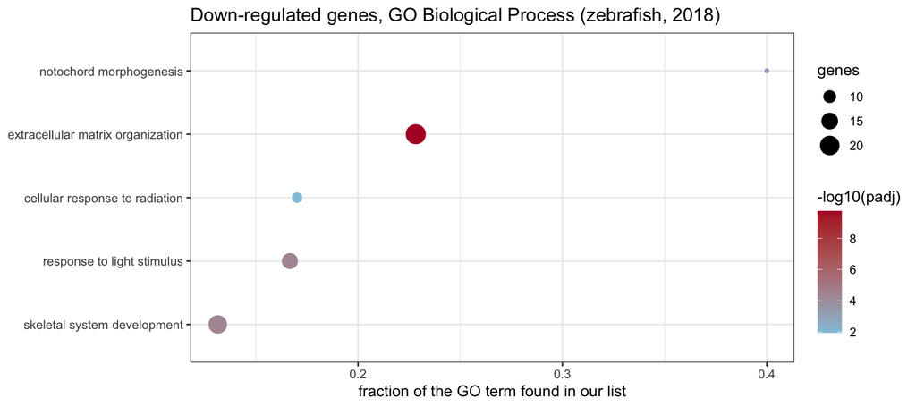

```r
# "Overlap" is stored as text, e.g. "21/92". Split it to compute a gene ratio.
plot_data = sig_down %>%
  mutate(
    n_genes   = as.numeric(sub("/.*", "", Overlap)),
    term_size = as.numeric(sub(".*/", "", Overlap)),
    ratio     = n_genes / term_size,
    # Adjusted p-values span several orders of magnitude, so colour on a
    # -log10 scale; on a linear scale most points would share one colour.
    neg_log10_padj = -log10(`Adjusted P-value`),
    Term      = sub(" \\(GO:.*", "", Term)          # drop the GO id for the label
  )

ggplot(plot_data, aes(x = ratio, y = reorder(Term, ratio))) +
  geom_point(aes(size = n_genes, colour = neg_log10_padj)) +
  scale_colour_gradient(low = "#92c5de", high = "#b2182b") +
  labs(x = "fraction of the GO term found in our list",
       y = NULL,
       size = "genes",
       colour = "-log10(padj)",
       title = "Down-regulated genes, GO Biological Process (zebrafish, 2018)") +
  theme_bw()
```

## 8. Inspect the genes behind each term

A significant term does not by itself establish a biological conclusion. GO annotations are assigned by curators and automated pipelines, and a term name may not describe why a gene set was selected. The `Genes` column lists the genes that contribute to each term and should be checked before a result is reported.

```r
sig_down %>%
  dplyr::select(Term, Overlap, Genes) %>%
  dplyr::mutate(Term = sub(" \\(GO:.*", "", Term)) %>%
  as.data.frame()
```

```
##                                Term Overlap
## 1 extracellular matrix organization   21/92
## 2        response to light stimulus   14/84
## 3       skeletal system development  18/137
## 4           notochord morphogenesis    6/15
## 5    cellular response to radiation    8/47
##                                                                                                                                                                        Genes
## 1 col27a1a;col27a1b;col2a1a;col28a1a;col5a2a;col5a3b;col8a1a;col11a2;col17a1a;zgc:113232;col10a1a;col11a1b;col8a2;col4a5;col9a3;col9a2;col9a1a;loxl3a;col1a1a;col1a1b;col1a2
## 2                                                                                      per2;per3;cry5;rhol;opn4a;rlbp1a;opn1sw1;opn1sw2;per1a;rho;opn1lw2;opn1mw1;npas2;ddb2
## 3                                                      col27a1a;col27a1b;col2a1a;cmn;egf;vcanb;col11a2;spp1;myhz2;matn1;camk1da;and2;and1;wisp3;col1a1a;col1a1b;col1a2;ucmab
## 4                                                                                                                                 col27a1a;col27a1b;col8a1a;fbn2b;loxl5b;ngs
## 5                                                                                                                        opn1sw1;opn1sw2;rhol;rho;opn4a;opn1lw2;opn1mw1;bbc3
```

Points to note in this table:

**Gene families.** Nineteen of the 21 genes in “extracellular matrix organization” are collagens; the other two are `loxl3a`, a collagen cross-linking enzyme, and `zgc:113232`, an uncharacterised gene. The term mainly reflects changes in collagen genes.

**Shared genes between terms.** “Notochord morphogenesis” shares 3 of its 6 genes with the extracellular matrix term, and “skeletal system development” shares 7 of its 18. These terms are partly redundant and should not be counted as independent results.

**Term names.** “Cellular response to radiation” contains `opn1sw1`, `opn1sw2`, `opn1lw2`, `opn1mw1` (cone opsins), `rho` and `rhol` (rhodopsin and rhodopsin-like), `opn4a` (melanopsin) and `bbc3`. The experiment did not involve radiation. The seven light-sensitive genes are annotated to this term because light is electromagnetic radiation. `bbc3` (PUMA) is a DNA-damage response gene, but a single gene does not support the term.

The same seven genes are also part of “response to light stimulus”. That term has 14 genes, five of which are circadian clock genes (`per1a`, `per2`, `per3`, `cry5`, `npas2`), so it combines two separate signals examined in section 9.

As a general rule, report a GO term only after checking the genes that produced it.

## 9. Exercise: photoreceptor and clock genes

The samples are described as dissected hearts at 48 hpf.

```r
res %>%
  dplyr::filter(gene %in% c("rho", "crx", "opn1sw1", "opn1sw2", "opn1lw2", "opn1mw1")) %>%
  dplyr::select(gene, baseMean, log2FoldChange, padj) %>%
  dplyr::arrange(dplyr::desc(baseMean))
```

```
## # A tibble: 6 x 4
##   gene    baseMean log2FoldChange     padj
##   <chr>      <dbl>          <dbl>    <dbl>
## 1 crx       2916.           -1.02 4.77e- 5
## 2 rho       2108.           -1.21 2.39e-13
## 3 opn1lw2    788.           -2.69 7.20e-19
## 4 opn1sw1    354.           -2.68 5.52e- 4
## 5 opn1sw2    130.           -2.82 1.52e- 8
## 6 opn1mw1     60.2          -3.00 9.22e- 6
```

`baseMean` is the mean normalised expression across all samples. `rho` has a baseMean of about 2,100 and `crx`, a transcription factor required for photoreceptor development, about 2,900.

**Question.** Is this more likely to reflect an effect of the mutation or a property of the samples? What would you check next?

Repeat for the following genes and consider whether the same explanation applies:

```r
res %>%
  dplyr::filter(gene %in% c("per1a", "per2", "per3", "nr1d1", "npas2", "cry5")) %>%
  dplyr::select(gene, baseMean, log2FoldChange, padj) %>%
  dplyr::arrange(log2FoldChange)
```

```
## # A tibble: 6 x 4
##   gene  baseMean log2FoldChange     padj
##   <chr>    <dbl>          <dbl>    <dbl>
## 1 per1a     183.          -1.53 1.31e-11
## 2 per2     1810.          -1.38 7.52e-12
## 3 cry5      182.          -1.21 3.17e- 3
## 4 nr1d1     165.          -1.19 2.38e- 5
## 5 npas2     102.          -1.16 7.35e- 7
## 6 per3     1220.          -1.05 1.25e-13
```

Both groups of genes are significantly changed. Photoreceptor genes at this level suggest that eye tissue is present in the samples. A coordinated shift in clock genes is consistent with samples collected at different times of day. Signals of this kind should be identified and reported as possible confounders rather than interpreted as effects of the mutation.

## 10. Exercise: overlap with a curated gene list

`data/chd_genes.annotations.tsv` contains 276 genes associated with congenital heart disease (CHD). Since the mutant is a heart model, one might expect these genes to be over-represented among the differentially expressed genes.

```r
chd = read_tsv("../../data/chd_genes.annotations.tsv", show_col_types = FALSE)

# The CHD list uses human symbols (upper case); ours are zebrafish (lower case).
chd_symbols = tolower(chd$gene_symbol)

in_chd = tolower(res$gene) %in% chd_symbols
is_de  = res$gene %in% de$gene

# How many CHD symbols exist in this dataset at all? A symbol that never
# matches cannot contribute to the test below.
length(intersect(chd_symbols, tolower(res$gene)))
```

```
## [1] 127
```

```r
length(unique(chd_symbols))
```

```
## [1] 276
```

```r
table(CHD = in_chd, DE = is_de)
```

```
##        DE
## CHD     FALSE  TRUE
##   FALSE 12692   936
##   TRUE    121     6
```

```r
fisher.test(table(in_chd, is_de))$p.value
```

```
## [1] 0.4775667
```

Note the two counts printed above: only 127 of the 276 CHD symbols match a zebrafish symbol at all, so 149 genes never enter the test. A negative result has to be read in the light of how much of the input was actually testable.

**Question.** The overlap is not significant. Does this mean the CHD genes are not relevant to this experiment? Check which CHD genes are differentially expressed before answering:

```r
res %>%
  dplyr::filter(tolower(gene) %in% chd_symbols, gene %in% de$gene) %>%
  dplyr::select(gene, baseMean, log2FoldChange, padj) %>%
  dplyr::arrange(log2FoldChange)
```

```
## # A tibble: 6 x 4
##   gene   baseMean log2FoldChange     padj
##   <chr>     <dbl>          <dbl>    <dbl>
## 1 mgp        7.28          -2.87 2.27e- 2
## 2 lox      104.            -1.89 5.83e- 6
## 3 col1a2 55512.            -1.16 8.26e- 7
## 4 col4a5 17491.            -1.14 4.83e-16
## 5 dhcr24   385.            -1.02 2.31e- 8
## 6 acta2   1119.             1.94 2.18e-68
```

Matching symbols by converting them to lower case is only an approximation of cross-species mapping. It finds `col1a2` but misses `col1a1a` and `col1a1b`, the two zebrafish copies of human `COL1A1` that arose from the teleost genome duplication. Ortholog mapping is covered in S7.